# DATA 622 Assignment 1

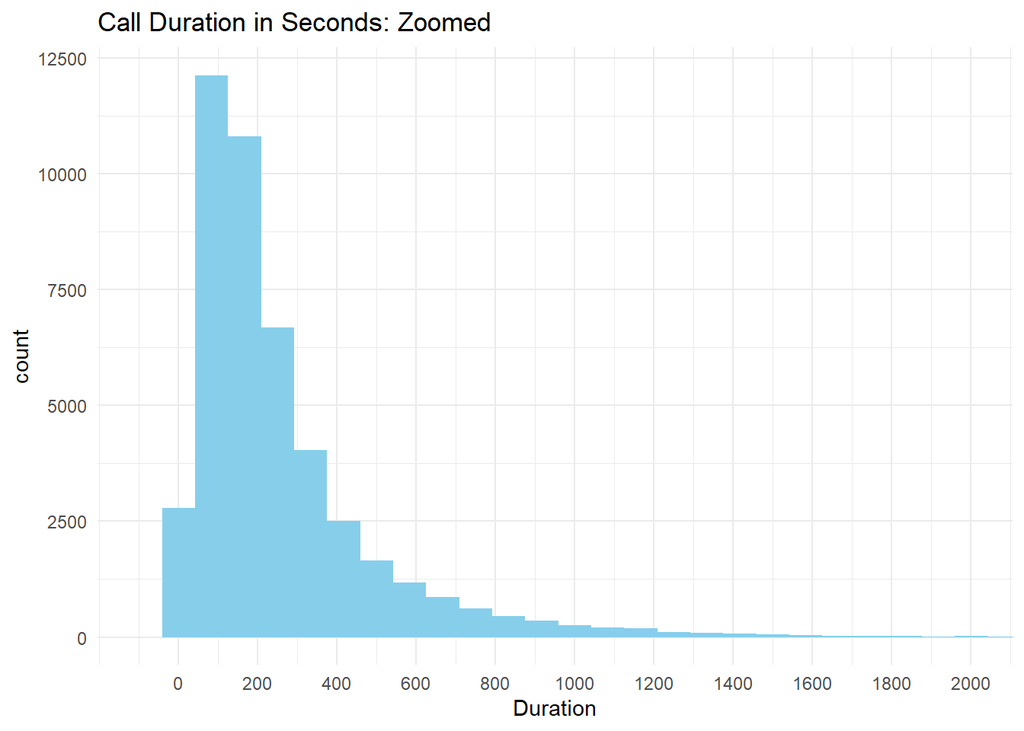

```r
ggplot(df_num, aes(x = Duration)) +
  geom_histogram(bins = 60, fill = "skyblue") +
  theme_minimal() +
  coord_cartesian(c(-100,2000)) +
  scale_x_continuous(breaks = seq(0, 2000, by = 200)) +
  labs(title = "Call Duration in Seconds: Zoomed")
```

```r
#---------------------------------
# Contacts Before This Campaign
summary(df_num$Contacts_Before_This_Campaign)
```

```
##     Min.  1st Qu.   Median     Mean  3rd Qu.     Max.
##   0.0000   0.0000   0.0000   0.5803   0.0000 275.0000
```

```r
df_final %>%
  count(Contacts_Before_This_Campaign) %>%
  #  mutate(Pct = round((n / sum(n)) * 100, 1))
  mutate(
    Contacts = ifelse(Contacts_Before_This_Campaign <= 5,
                      as.character(Contacts_Before_This_Campaign),
                      ">5"),
    Pct = round((n / sum(n)) * 100, 1)
  ) %>%
  group_by(Contacts) %>%
  summarise(n = sum(n), Pct = sum(Pct)) %>%
  arrange(as.numeric(Contacts)) %>%
  print(n = Inf)  # Show all rows (helpful in case there's 0-9 and "Other")
```

```
## # A tibble: 7 × 3
##   Contacts     n   Pct
##   <chr>    <int> <dbl>
## 1 0        36954  81.7
## 2 1         2772   6.1
## 3 2         2106   4.7
## 4 3         1142   2.5
## 5 4          714   1.6
## 6 5          459   1
## 7 >5        1064   2
```

```r
#---------------------------------
# Contacts This Campaign
summary(df_num$Contacts_This_Campaign)
```

```
##    Min. 1st Qu.  Median    Mean 3rd Qu.    Max.
##   1.000   1.000   2.000   2.764   3.000  63.000
```

```r
df_final %>%
  count(Contacts_This_Campaign) %>%
  #  mutate(Pct = round((n / sum(n)) * 100, 1))
  mutate(
    Contacts = ifelse(Contacts_This_Campaign <= 9,
                      as.character(Contacts_This_Campaign),
                      ">9"),
    Pct = round((n / sum(n)) * 100, 1)
  ) %>%
  group_by(Contacts) %>%
  summarise(n = sum(n), Pct = sum(Pct)) %>%
  arrange(as.numeric(Contacts)) %>%
  print(n = Inf)  # Show all rows (helpful in case there's 0-9 and "Other")
```

```
## # A tibble: 10 × 3
##    Contacts     n   Pct
##    <chr>    <int> <dbl>
##  1 1        17544  38.8
##  2 2        12505  27.7
##  3 3         5521  12.2
##  4 4         3522   7.8
##  5 5         1764   3.9
##  6 6         1291   2.9
##  7 7          735   1.6
##  8 8          540   1.2
##  9 9          327   0.7
## 10 >9        1462   2.9
```

```r
#---------------------------------
# Days Since Last Campaign
summary(df_num$Days_Since_Last_Campaign)
```

```
##    Min. 1st Qu.  Median    Mean 3rd Qu.    Max.
##    -1.0    -1.0    -1.0    40.2    -1.0   871.0
```

```r
df_final %>%
  count(Days_Since_Last_Campaign) %>%
  #  mutate(Pct = round((n / sum(n)) * 100, 1))
  mutate(
    Days = ifelse(Days_Since_Last_Campaign <= 5,
                  as.character(Days_Since_Last_Campaign),
                  ">5"),
    Pct = round((n / sum(n)) * 100, 1)
  ) %>%
  group_by(Days) %>%
  summarise(n = sum(n), Pct = sum(Pct)) %>%
  arrange(as.numeric(Days)) %>%
  print()
```

```
## # A tibble: 7 × 3
##   Days      n   Pct
##   <chr> <int> <dbl>
## 1 -1    36954  81.7
## 2 1        15   0
## 3 2        37   0.1
## 4 3         1   0
## 5 4         2   0
## 6 5        11   0
## 7 >5     8191  14.4
```

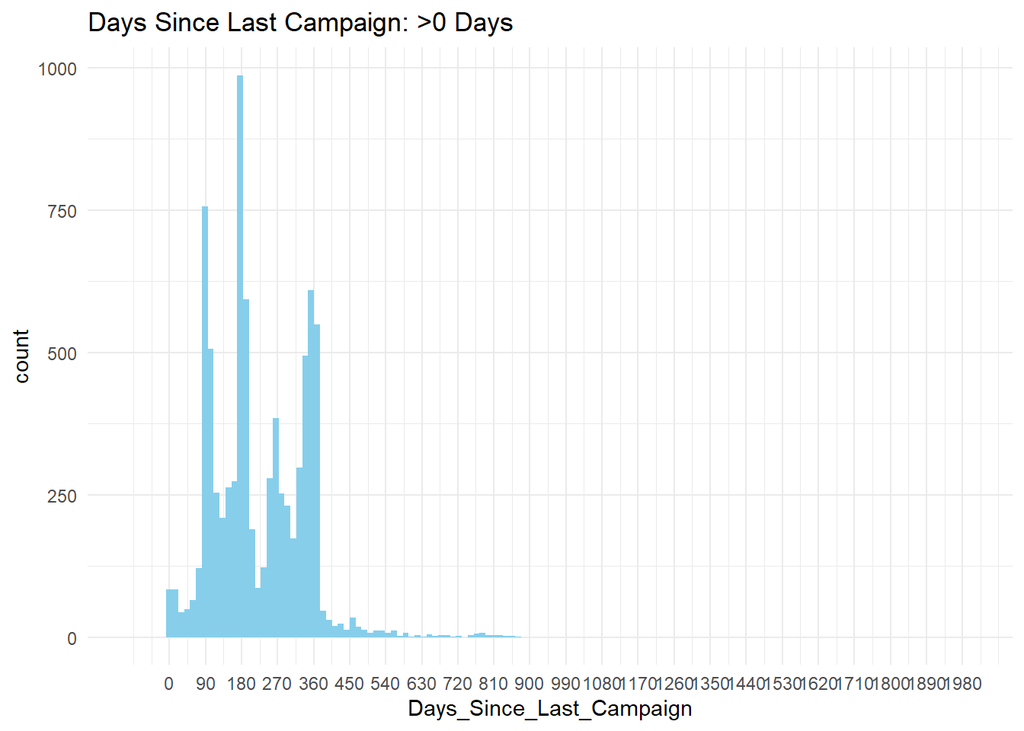

```r
# Remove -1 before charting
df_days_gt_0 <- df_num %>%
  select(Days_Since_Last_Campaign) %>%
  filter(Days_Since_Last_Campaign > 0)

ggplot(df_days_gt_0, aes(x = Days_Since_Last_Campaign)) +
  geom_histogram(bins = 60, fill = "skyblue") +
  theme_minimal() +
  coord_cartesian(c(-100,2000)) +
  scale_x_continuous(breaks = seq(0, 2000, by = 90)) +
  labs(title = "Days Since Last Campaign: >0 Days")
```

#### Relationships Between Variables

Bar charts and box plots were used to compare **categorical/numeric** and **categorical/categorical pairs**. Most pairs were not meaningful but several meaningful relationships were found, with some plots created for the essay.

```r
# Numeric/Numeric
cor_matrix <- df_num %>%
  cor(use = "pairwise.complete.obs")

# table of pairs with coefficients
cor_df <- as.data.frame(as.table(cor_matrix)) %>%
  filter(Var1 != Var2) %>%
  filter(abs(Freq) > 0.1) %>%
  arrange(desc(abs(Freq)))

cor_df
```

```
##                            Var1                          Var2      Freq
## 1 Contacts_Before_This_Campaign      Days_Since_Last_Campaign 0.4548196
## 2      Days_Since_Last_Campaign Contacts_Before_This_Campaign 0.4548196
```

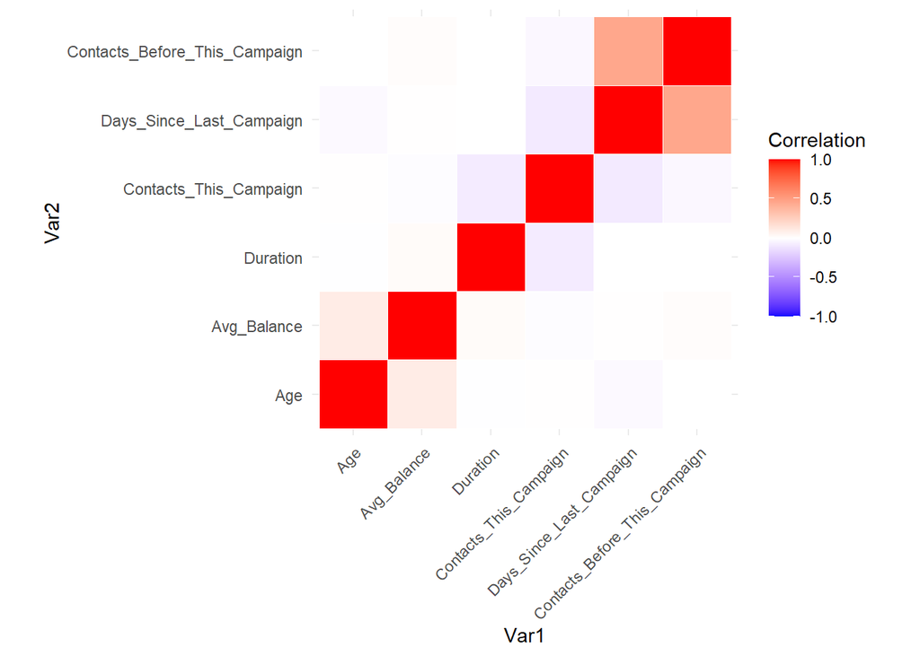

```r
# plot
melt_cor <- melt(cor_matrix)

ggplot(melt_cor, aes(Var1, Var2, fill = value)) +
  geom_tile(color = "white") +
  scale_fill_gradient2(low = "blue", high = "red", mid = "white",
                       midpoint = 0, limit = c(-1,1), space = "Lab",
                       name="Correlation") +
  theme_minimal() +
  theme(axis.text.x = element_text(angle = 45, vjust = 1, hjust = 1)) +
  coord_fixed()
```

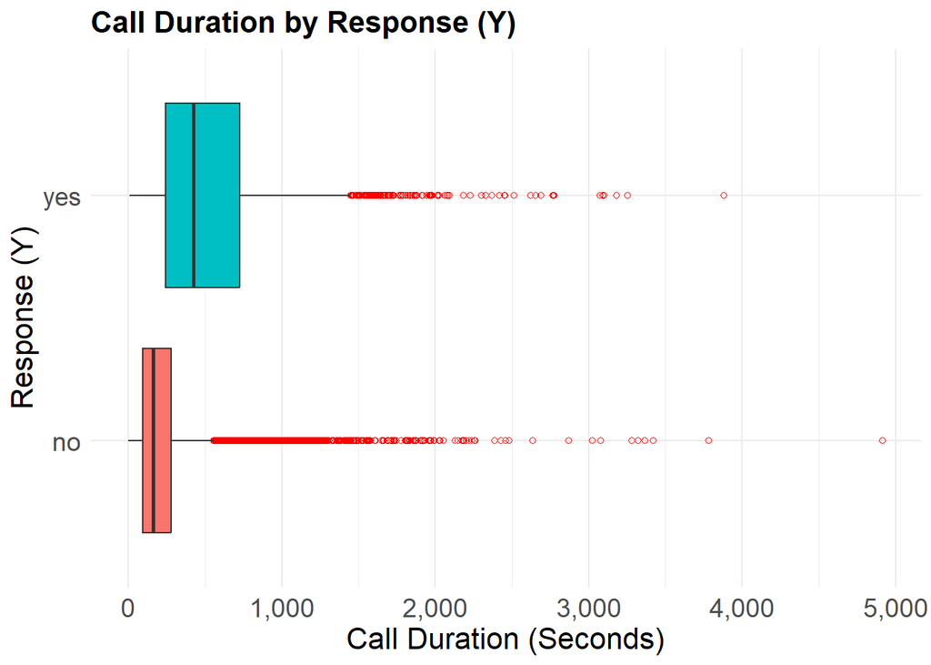

```r
#---------------------------------
# Categorical/Numeric Pairs
# (LOOP CREATES CHARTS FOR ALL PAIRS - COMMENTED OUT, very long)
#---------------------------------

num_cols <- df_num %>%
  names()

#for (cat in cat_cols) {
#  for (num in num_cols) {
#    p <- ggplot(df_final,
#                aes(x = .data[[cat]],
#                    y = .data[[num]])) +
#      geom_boxplot(outlier.color = "red", outlier.shape = 1) +
#      theme_minimal() +
#      theme(axis.text.x = element_text(angle = 45, hjust = 1)) +
#      labs(title = paste(num, "by", cat))

#    print(p)
#  }
#}

# SAMPLE FOR ESSAY
# call duration by Y
plot_duration_y <- df_final %>%
  ggplot(aes(x = Y, y = Duration, fill = Y)) +
  geom_boxplot(outlier.color = "red", outlier.shape = 1) +
  scale_y_continuous(labels = scales::comma) +
  labs(title = "Call Duration by Response (Y)",
       x = "Response (Y)",
       y = "Call Duration (Seconds)") +
  coord_flip() +
  theme_minimal() +
  theme(legend.position = "none",
        plot.title = element_text(size = 16, face = "bold"),
        axis.title.x = element_text(size = 16),
        axis.title.y = element_text(size = 16),
        axis.text.x = element_text(size = 14),
        axis.text.y = element_text(size = 14))

print(plot_duration_y)
```

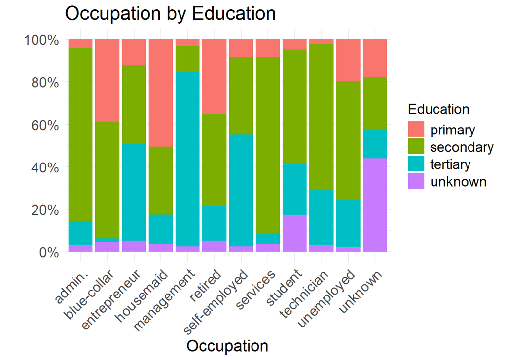

```r
#---------------------------------
# Categorical/Categorical Pairs
# (ALL PAIRS - COMMENTED OUT, very long!)
#---------------------------------

#if (length(cat_cols) > 1) {
#  for (i in 1:(length(cat_cols) - 1)) {
#    for (j in (i + 1):length(cat_cols)) {
#      cat1 <- cat_cols[i]
#      cat2 <- cat_cols[j]
#
#      p <- ggplot(df_final,
#                  aes(x = .data[[cat1]],
#                      fill = .data[[cat2]])) +
#        geom_bar(position = "fill") +
#        scale_y_continuous(labels = scales::label_percent()) +
#        labs(title = paste("Proportion of", cat2, "within", cat1),
#             y = "Proportion") +
#        theme_minimal() +
#        theme(axis.text.x = element_text(angle = 45, hjust = 1))
#
#      print(p)
#    }
#  }
#}

# SAMPLE FOR ESSAY
# occupation by education
plot_ed_occ <- df_final %>%
  ggplot(aes(x = Occupation, fill = Education)) +
    geom_bar(position = "fill") +
    labs(title = "Occupation by Education",
         x = "Occupation",
         y = "") +
    scale_y_continuous(labels = scales::percent_format(), breaks = pretty_breaks(6)) +
    theme_minimal() +
    theme(legend.position = "right",
          legend.text = element_text(size = 14),
          legend.title = element_text(size = 14),
          title = element_text(size = 16),
          axis.text.x = element_text(angle = 45, hjust = 1, size = 14),
          axis.title.x = element_text(size = 16),
          axis.title.y = element_text(size = 16),
          axis.text.y = element_text(size = 14))

print(plot_ed_occ)
```

#### Pre-Processing

This data was extremly clean, but based on the EDA above, I made two improvements:

1. Replaced -1 with NA in “Days Since Last Campaign” to more accurately identify first time contacts and avoid math issues
2. Created two new customer segmentation features to combine related features (occupation/education, borrowing profile) and simplify modeling

```r
# Replace -1 with NA
df_preprocessed <- df_final %>%
  mutate(Days_Since_Last_Campaign =
           ifelse(Days_Since_Last_Campaign == -1,
                  NA,
                  Days_Since_Last_Campaign))

# Results: Original and Revised
df_final %>%
  count(Days_Since_Last_Campaign) %>%
  mutate(
    Days = ifelse(Days_Since_Last_Campaign <= 5,
                  as.character(Days_Since_Last_Campaign),
                  ">5"),
    Pct = round((n / sum(n)) * 100, 1)
  ) %>%
  group_by(Days) %>%
  summarise(n = sum(n), Pct = sum(Pct)) %>%
  arrange(as.numeric(Days)) %>%
  print()
```

```
## # A tibble: 7 × 3
##   Days      n   Pct
##   <chr> <int> <dbl>
## 1 -1    36954  81.7
## 2 1        15   0
## 3 2        37   0.1
## 4 3         1   0
## 5 4         2   0
## 6 5        11   0
## 7 >5     8191  14.4
```

```r
df_preprocessed %>%
  count(Days_Since_Last_Campaign) %>%
  mutate(
    Days = ifelse(Days_Since_Last_Campaign <= 5,
                  as.character(Days_Since_Last_Campaign),
                  ">5"),
    Pct = round((n / sum(n)) * 100, 1)
  ) %>%
  group_by(Days) %>%
  summarise(n = sum(n), Pct = sum(Pct)) %>%
  arrange(as.numeric(Days)) %>%
  print()
```

```
## # A tibble: 7 × 3
##   Days      n   Pct
##   <chr> <int> <dbl>
## 1 1        15   0
## 2 2        37   0.1
## 3 3         1   0
## 4 4         2   0
## 5 5        11   0
## 6 >5     8191  14.4
## 7 <NA>  36954  81.7
```

```r
#---------------------------------
# occupation/education feature
df_preprocessed <- df_preprocessed %>%
  mutate(Occupation_Education = paste(Occupation, Education, sep = "_"))

df_preprocessed %>%
  count(Occupation_Education, sort = TRUE) %>%
  mutate(Pct = round((n / sum(n)) * 100, 1))
```

```
## # A tibble: 48 × 3
##    Occupation_Education       n   Pct
##    <chr>                  <int> <dbl>
##  1 management_tertiary     7801  17.3
##  2 blue-collar_secondary   5371  11.9
##  3 technician_secondary    5229  11.6
##  4 admin._secondary        4219   9.3
##  5 blue-collar_primary     3758   8.3
##  6 services_secondary      3457   7.6
##  7 technician_tertiary     1968   4.4
##  8 management_secondary    1121   2.5
##  9 retired_secondary        984   2.2
## 10 self-employed_tertiary   833   1.8
## # ℹ 38 more rows
```

```r
#---------------------------------
# loan profile feature: default, housing, personal loans
df_preprocessed <- df_preprocessed %>%
  mutate(Loan_Profile = case_when(
    Housing_Loan == "yes" & Personal_Loan == "yes" & In_Default == "yes" ~ "Both Loans - In Default",
    Housing_Loan == "yes" & Personal_Loan == "yes" & In_Default == "no" ~ "Both Loans - No Default",
    Housing_Loan == "yes" & Personal_Loan == "no" & In_Default == "yes" ~ "Housing Loan - In Default",
    Housing_Loan == "yes" & Personal_Loan == "no" & In_Default == "no" ~ "Housing Loan - No Default",
    Housing_Loan == "no" & Personal_Loan == "yes" & In_Default == "yes" ~ "Personal Loan - In Default",
    Housing_Loan == "no" & Personal_Loan == "yes" & In_Default == "no" ~ "Personal Loan - No Default",
    Housing_Loan == "no" & Personal_Loan == "no" & In_Default == "yes" ~ "No Loans - In Default",
    TRUE ~ "No Loans - No Default"
  ))

df_preprocessed %>%
  count(Loan_Profile, sort = TRUE) %>%
  mutate(Pct = round((n / sum(n)) * 100, 1))
```

```
## # A tibble: 8 × 3
##   Loan_Profile                   n   Pct
##   <chr>                      <int> <dbl>
## 1 Housing Loan - No Default  20461  45.3
## 2 No Loans - No Default      16992  37.6
## 3 Both Loans - No Default     4234   9.4
## 4 Personal Loan - No Default  2709   6
## 5 Housing Loan - In Default    302   0.7
## 6 No Loans - In Default        212   0.5
## 7 Personal Loan - In Default   168   0.4
## 8 Both Loans - In Default      133   0.3
```